# Unsupervised Learning in Action: Discovering Patterns Without Labels

# Section 2: Study Using **DBSCAN and OPTICS**

## Data Preparation

Before proceeding, we need to understand **both clustering algorithms**.

We found the following information:

**[OPTICS Algorithm - Wikipedia](https://en.wikipedia.org/wiki/OPTICS_algorithm)**

- The **OPTICS algorithm** (*Ordering Points to Identify the Clustering Structure*) is a **density-based clustering method**.
- It is **similar to DBSCAN but more flexible**.
- OPTICS **orders data points** so that **closer points are grouped first**.
- It uses **two parameters**:
  - **ε (maximum radius)**
  - **MinPts (minimum number of points to form a cluster)**
- Each point receives a **reachability distance**, representing the **density required to form a cluster**.
- **OPTICS is particularly useful** for detecting clusters in **datasets with varying densities**.

We chose **MinPts = 10**, based on the **example exercise** and the following reference:

**[How to Determine Epsilon and MinPts for DBSCAN](https://www.sefidian.com/2022/12/18/how-to-determine-epsilon-and-minpts-parameters-of-dbscan-clustering/)**

- In **practice and literature**, a **MinPts value between 5 and 10** is **commonly used**.
- This range **balances sensitivity to clusters and resistance to outliers**.
- A **MinPts of 10** provides **enough flexibility** to adapt to **data variability**.

We will use the **normalized dataset**, **excluding dummy variables**.

After the **initial analysis**, we will assess whether **repeating the experiment with dummy variables is necessary**.

```r
hawks_scaled2 <- hawks_scaled %>%
  select(Wing, Weight, Culmen, Hallux)
hawks_scaled2
```

```
##            Wing       Weight      Culmen      Hallux
## 1    0.72901533  0.323037860  0.53643756  0.58802795
## 2    0.63453308  0.344646534  0.68899769  0.84440031
## 3    0.68702322  0.474298581  0.67363520  0.73239710
## 4   -0.53074792 -0.649352494 -0.42394592 -0.20600240
## 5   -1.16062955 -1.297612730 -1.27457130 -1.31283258
## 6    1.01246206  0.690385326  0.92059096  0.84067397
## 7    0.57154492  0.409472558  0.48155851  0.58802795
## 8    0.62403506  0.182581475  0.74223402  0.57599719
## 9    1.01246206  0.949689421  1.03034907  0.73239710
## 10   0.93897587  0.755211350  0.57759685  0.60005871
## 11   0.81299955  0.517515930  0.61875615  0.67224329
## 12   0.58204295  0.517515930  0.49527827  0.53990490
## 13   0.78150546  0.755211350  0.97547001  0.68427405
## 14   0.81299955  0.844699836  0.87943166  0.64818176
```

[output cut: 894 more lines]

## OPTICS

```r
res <- optics(hawks_scaled2, minPts = 10)
res
```

```
## OPTICS ordering/clustering for 908 objects.
## Parameters: minPts = 10, eps = 3.07488223798005, eps_cl = NA, xi = NA
## Available fields: order, reachdist, coredist, predecessor, minPts, eps,
##                   eps_cl, xi
```

The data indicates that **3.07488223798005** is the **maximum neighborhood size** to consider when determining proximity between data points.

```r
res$order
```

```
##   [1]   1 571 390 267 260 245 620 185 184 150 149 137  93 824 764 650 408 233
##  [19] 193  25 236 487 481 426 378 317 787 771 594 467 281  12  87 134 119 278
##  [37] 203 765 334 861 844 701 471 223 283 116 648 891 832 707 681 547 508 337
##  [55] 762 579 139 251  80   7 165 555 365 532 131  11 402 784 295 364 206 515
##  [73] 457 876 561 550 391  33 222 774 717 552 292 403 372 250 823 506 460 179
##  [91] 154  48  43 758 589 871 848 671 450  79 898 760 473   3 113 715 423 483
## [109] 438 427 270 647 135  90  31 696 782 740 590 182 323 190 157 342 800 465
## [127] 338 180 178 679 181 354 556 778 726 528 437 526  45 355 743 649 582 336
## [145] 155 544 855 309 615 854 893 169 274 585 240 110  21 572 433 183 692 862
## [163]   2  51 286 789 733 324 719 846 560 505 478 867 878 576 466 434 380 230
## [181]  19 853 489 504 114 194 617 136 138  71 709 258 770 290 205 237 596 780
## [199] 775 602 600 601 581 397 745 117 907 868 674 676 537  32 553 412 177 173
## [217]  49 200 672 606 593 151 559 605 881 769 496 531 888 197 159 123 385 883
## [235] 882 614 540 901 744 558 369 497 209 208 204 455 694 275 609 514 367 608
## [253] 892 812 631 566 501 405 300 785 199  47 224  72 691 207  10 294  46 153
```

[output cut: 36 more lines]

The **OPTICS point ordering** arranges data based on **density**, revealing the **cluster structure**.

To **better visualize the valleys**, we will **plot the reachability plot**, making it clearer to determine the **optimal number of clusters**.

We observe **two large valleys** (**first indication, similar to K-Means**) and **three smaller ones**, with one being **more prominent**, leading to a **preliminary conclusion of 3 clusters**.

If we **consider all valleys**, we might **identify 5 clusters**.

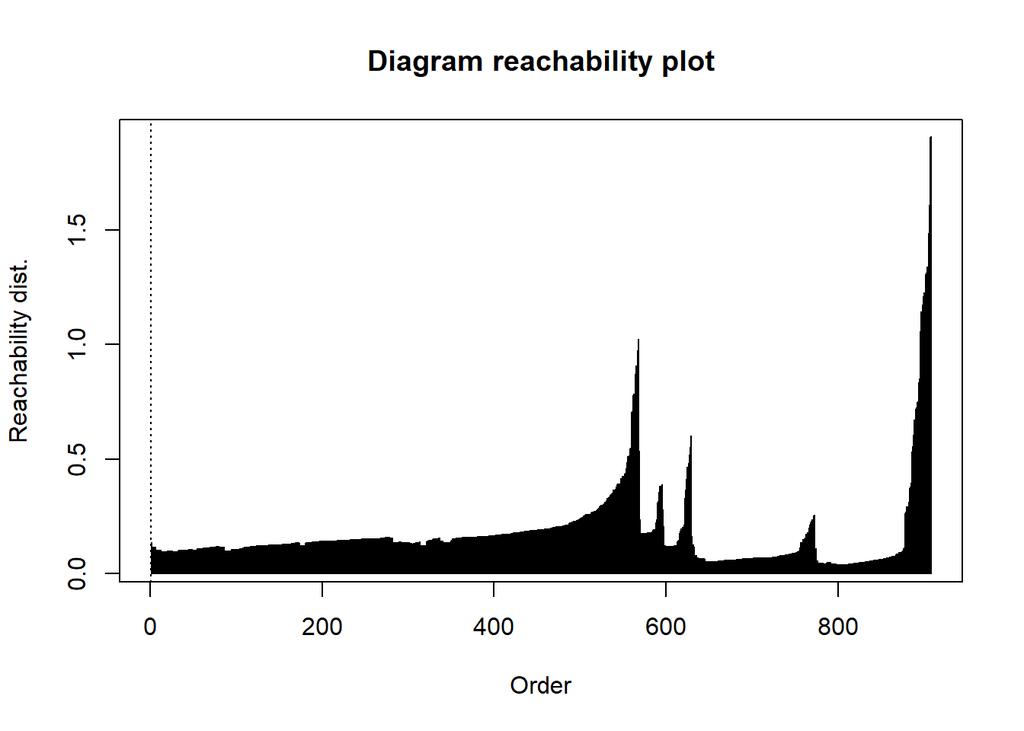

```r
plot(res, main= "Diagram reachability plot")
```

Now, we will **visualize the clusters** using the **variables from our normalized dataset**.

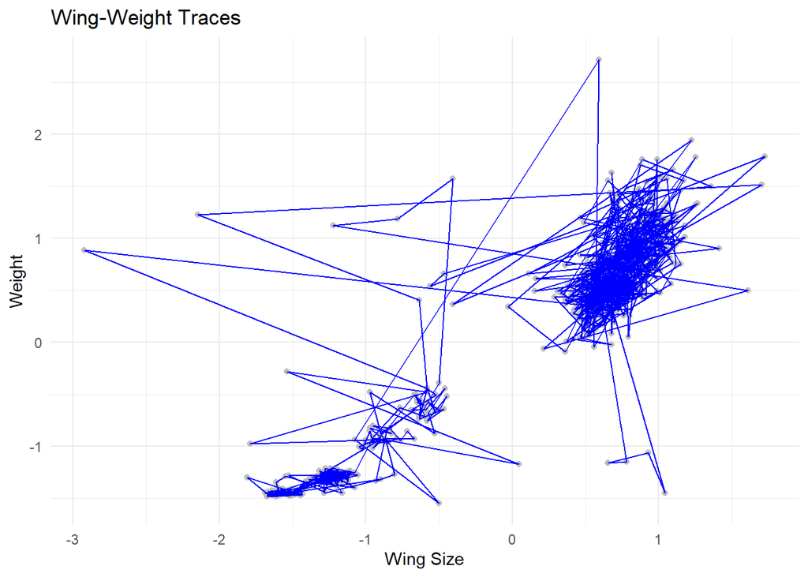

```r
hawks_plot <- data.frame(
  Wing = hawks_scaled2$Wing,
  Weight = hawks_scaled2$Weight,
  Culmen = hawks_scaled2$Culmen,
  Hallux = hawks_scaled2$Hallux,
  Order = res$order
)

ggplot(hawks_plot, aes(x = Wing, y = Weight)) +
  geom_point(color = "grey") +
  geom_polygon(aes(x = Wing[Order], y = Weight[Order]), fill = NA, color = "blue") +
  ggtitle("Wing-Weight Traces") +
  xlab("Wing Size") +
  ylab("Weight") +
  theme_minimal()
```

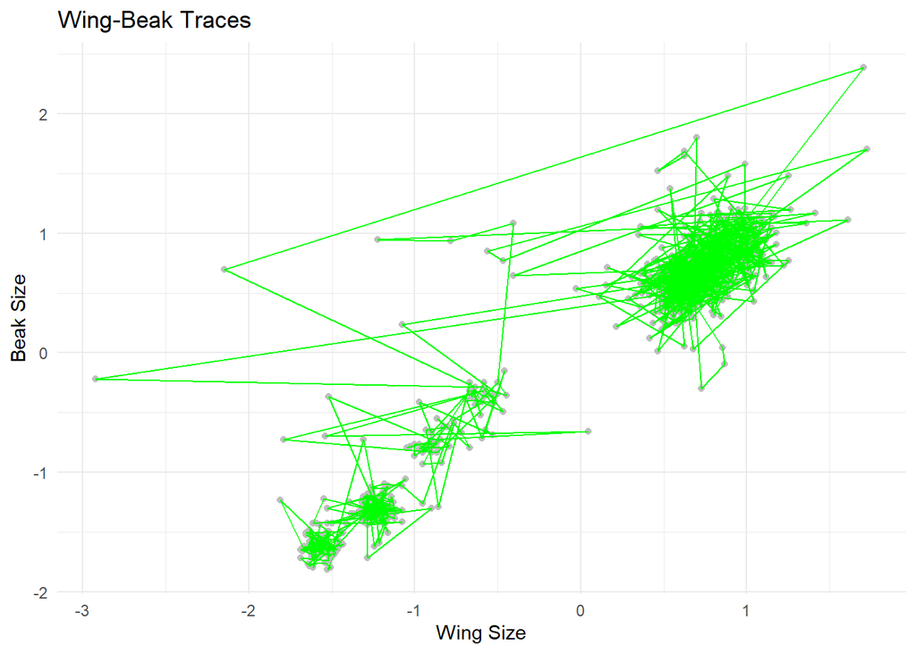

```r
ggplot(hawks_plot, aes(x = Wing, y = Culmen)) +
  geom_point(color = "grey") +
  geom_polygon(aes(x = Wing[Order], y = Culmen[Order]), fill = NA, color = "green") +
  ggtitle("Wing-Beak Traces") +
  xlab("Wing Size") +
  ylab("Beak Size") +
  theme_minimal()
```

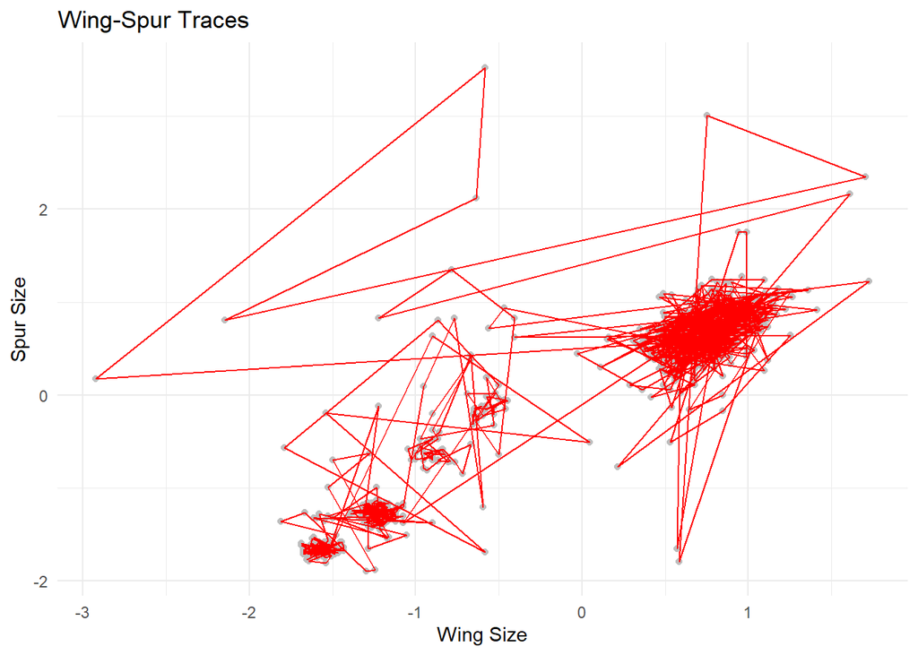

```r
ggplot(hawks_plot, aes(x = Wing, y = Hallux)) +
  geom_point(color = "grey") +
  geom_polygon(aes(x = Wing[Order], y = Hallux[Order]), fill = NA, color = "red") +
  ggtitle("Wing-Spur Traces") +
  xlab("Wing Size") +
  ylab("Spur Size") +
  theme_minimal()
```

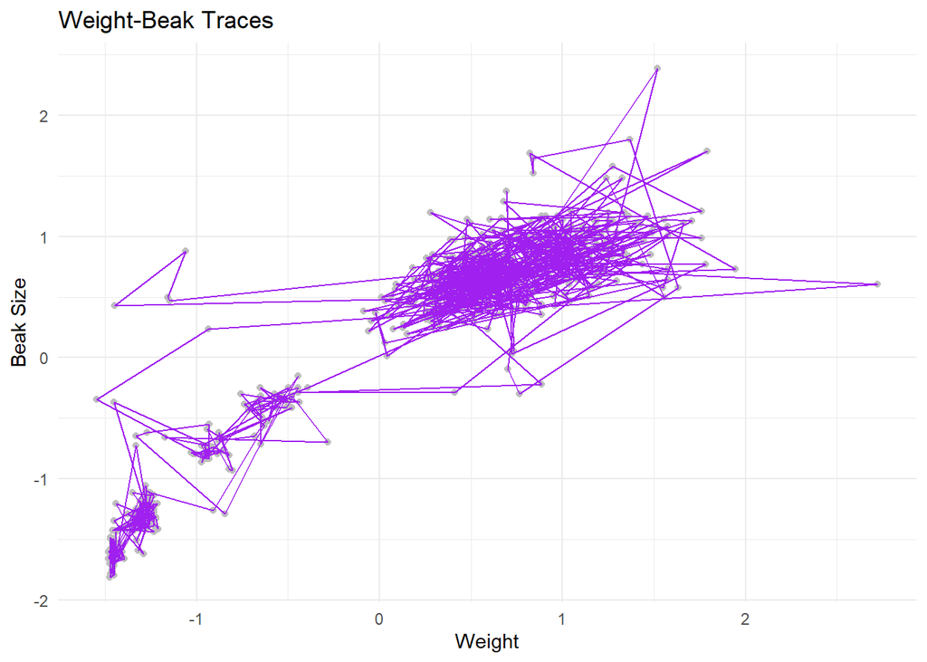

```r
ggplot(hawks_plot, aes(x = Weight, y = Culmen)) +
  geom_point(color = "grey") +
  geom_polygon(aes(x = Weight[Order], y = Culmen[Order]), fill = NA, color = "purple") +
  ggtitle("Weight-Beak Traces") +
  xlab("Weight") +
  ylab("Beak Size") +
  theme_minimal()
```

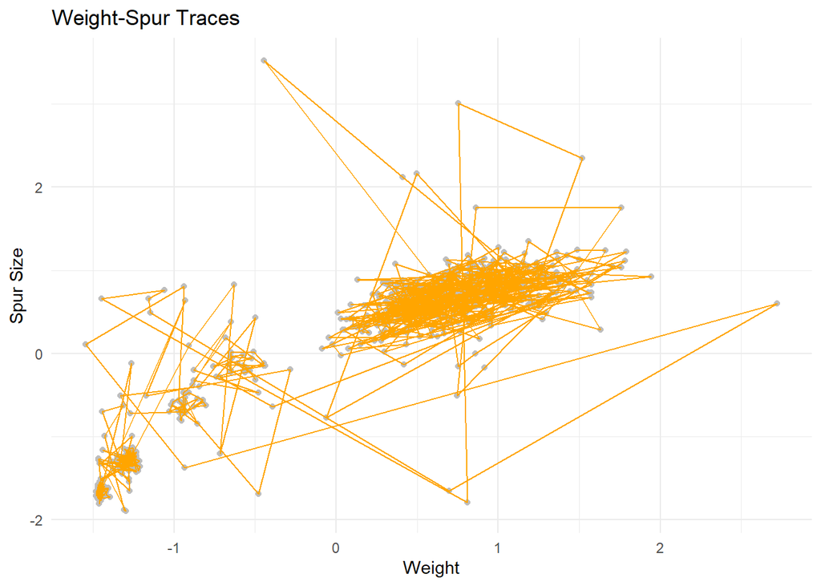

```r
ggplot(hawks_plot, aes(x = Weight, y = Hallux)) +
  geom_point(color = "grey") +
  geom_polygon(aes(x = Weight[Order], y = Hallux[Order]), fill = NA, color = "orange") +
  ggtitle("Weight-Spur Traces") +
  xlab("Weight") +
  ylab("Spur Size") +
  theme_minimal()
```

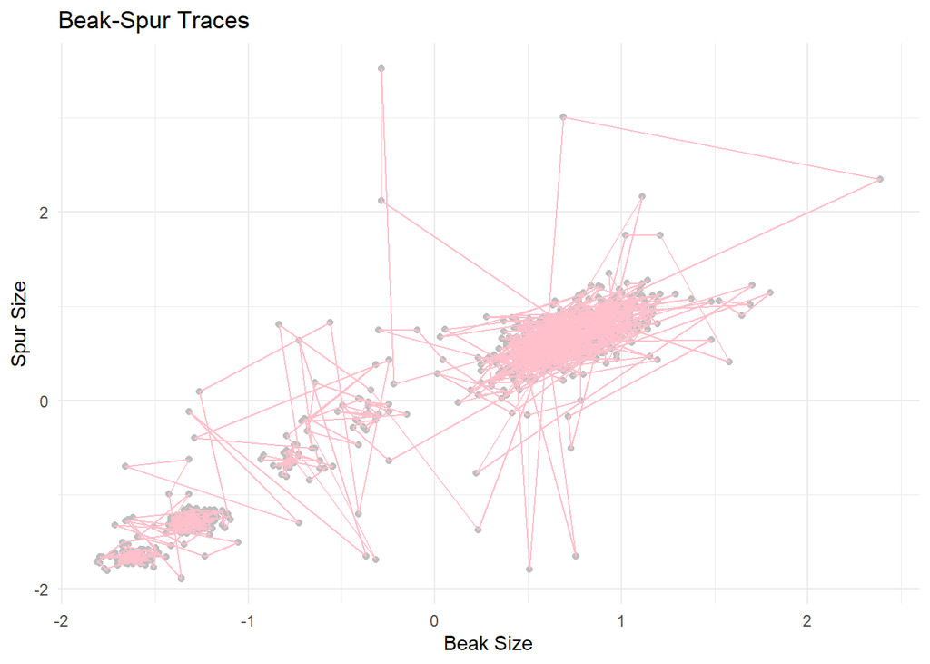

```r
ggplot(hawks_plot, aes(x = Culmen, y = Hallux)) +
  geom_point(color = "grey") +
  geom_polygon(aes(x = Culmen[Order], y = Hallux[Order]), fill = NA, color = "pink") +
  ggtitle("Beak-Spur Traces") +
  xlab("Beak Size") +
  ylab("Spur Size") +
  theme_minimal()
```

This type of chart is complex to interpret, so we created another one where we grouped everything to observe clearer patterns.

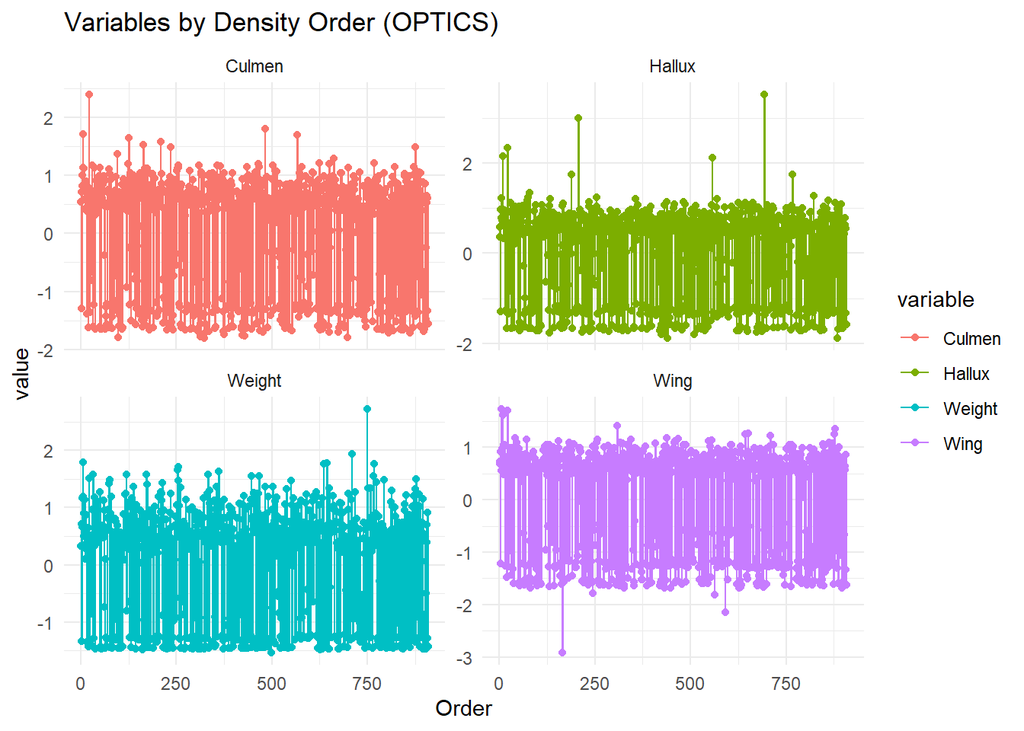

```r
hawks_long <- hawks_plot %>%
  pivot_longer(cols = c(Wing, Weight, Culmen, Hallux), names_to = "variable", values_to = "value")

ggplot(hawks_long, aes(x = Order, y = value, color = variable)) +
  geom_point() +
  geom_line(aes(group = variable)) +
  facet_wrap(~ variable, scales = "free_y") +
  ggtitle("Variables by Density Order (OPTICS)") +
  theme_minimal()
```

**Wing vs. Weight Relationship**  
We can see clear groupings in the *Wing vs. Weight* plots. This suggests that wing size and weight are characteristics that may help distinguish between hawk species. For example, larger and heavier hawks might belong to a specific species, while smaller and lighter ones may belong to another.

**Wing vs. Culmen Relationship**  
The *Wing vs. Culmen* plot also shows groupings, indicating that wing size and beak size are correlated. This can be particularly useful for identifying species with specific beak and wing characteristics, such as *cooperative hawks*.

**Wing vs. Hallux Relationship**  
Although less obvious, the *Wing vs. Hallux* plot still shows some grouping patterns. The length of the spur, along with wing size, may differentiate certain species or ages within the same species.

**Species and Clusters**  
Finally, by including these measurements in the clustering analysis, we can infer that there are three main clusters corresponding to the three hawk species. The grouping observed in the plots confirms that physical characteristics have a significant impact on species classification.

## DBSCAN

Now, let’s move on to the second algorithm, DBSCAN.  
We are not sure what epsilon value to use, so we referred to this reference: **[How to find optimal epsilon value](https://blog.dailydoseofds.com/p/how-to-find-optimal-epsilon-value)**

Looking at the k-distance graph (we used 9 as indicated by `minPts - 1 = k`), we can see that the curve remains relatively flat for most of the points but starts to increase sharply towards the end. The point where the slope of the graph changes sharply is between 0.4 and 0.7 on the axis. This suggests that the mean should be around 0.55.

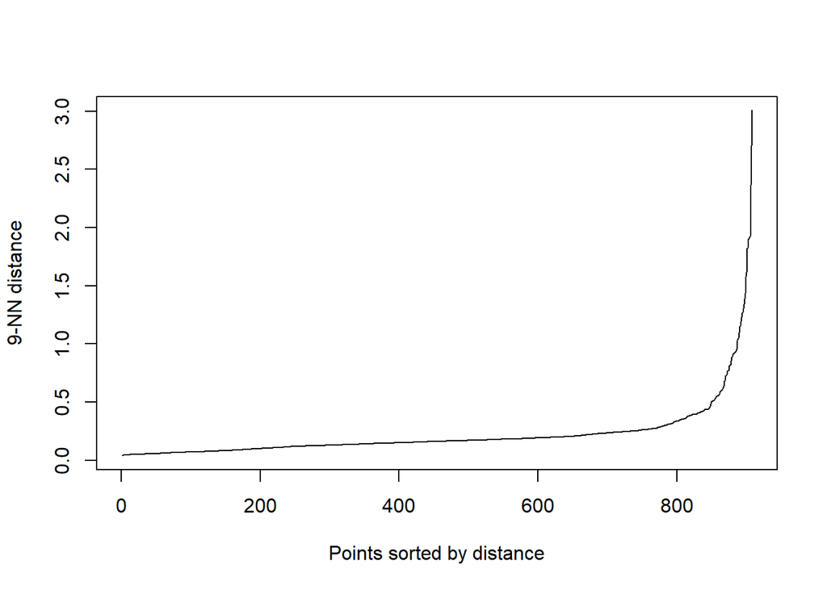

```r
k <- 9
kNNdistplot(hawks_scaled2, k = k)
```

The clusters contain **559**, **60**, and **258** points respectively, highlighting the structure of the data in specific densities and confirming the effectiveness of this epsilon value.

```r
res <- extractDBSCAN(res, eps_cl = 0.55)
res
```

```
## OPTICS ordering/clustering for 908 objects.
## Parameters: minPts = 10, eps = 3.07488223798005, eps_cl = 0.55, xi = NA
## The clustering contains 3 cluster(s) and 31 noise points.
##
##   0   1   2   3
##  31 559  60 258
##
## Available fields: order, reachdist, coredist, predecessor, minPts, eps,
##                   eps_cl, xi, cluster
```

We plotted the data and can clearly see the **3 clusters** and the corresponding **noise**.

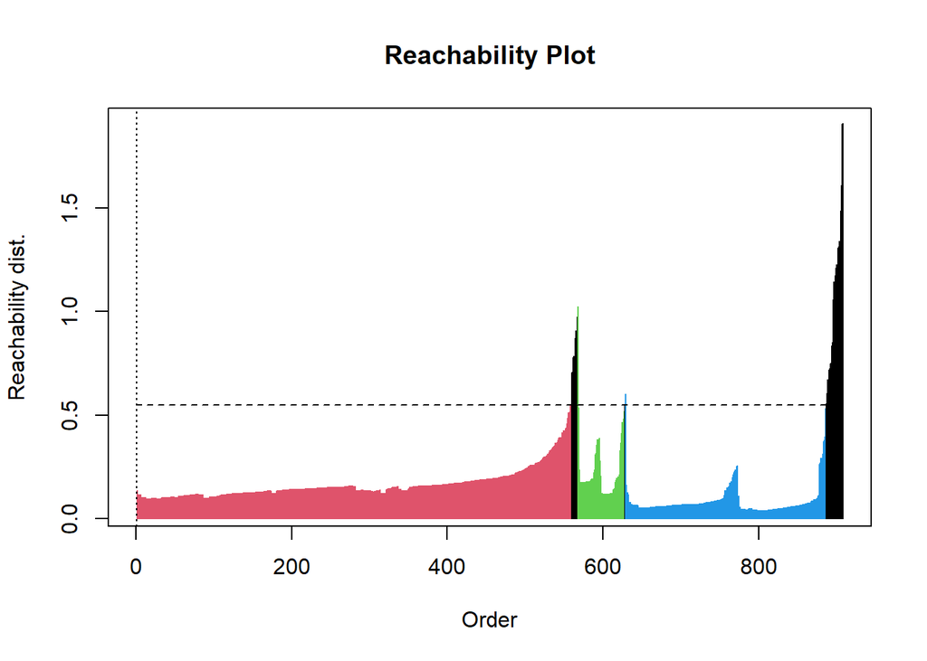

```r
plot(res)
```

We also plotted it additionally, where it is even clearer.

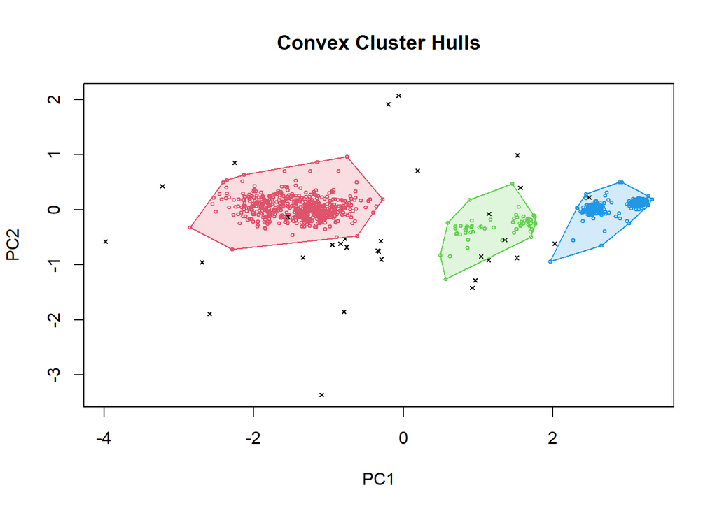

```r
hullplot(hawks_scaled2, res)
```

We will perform the same process but including our dummy variables for sex and age.

```r
hawks_scaled
```

```
##            Wing       Weight      Culmen      Hallux Sex_M Sex_F Age_A Age_I
## 1    0.72901533  0.323037860  0.53643756  0.58802795     0     0     0     1
## 2    0.63453308  0.344646534  0.68899769  0.84440031     0     0     0     1
## 3    0.68702322  0.474298581  0.67363520  0.73239710     0     0     0     1
## 4   -0.53074792 -0.649352494 -0.42394592 -0.20600240     0     1     0     1
## 5   -1.16062955 -1.297612730 -1.27457130 -1.31283258     0     1     0     1
## 6    1.01246206  0.690385326  0.92059096  0.84067397     0     0     0     1
## 7    0.57154492  0.409472558  0.48155851  0.58802795     0     0     0     1
## 8    0.62403506  0.182581475  0.74223402  0.57599719     0     0     1     0
## 9    1.01246206  0.949689421  1.03034907  0.73239710     0     0     1     0
## 10   0.93897587  0.755211350  0.57759685  0.60005871     0     0     0     1
## 11   0.81299955  0.517515930  0.61875615  0.67224329     0     0     0     1
## 12   0.58204295  0.517515930  0.49527827  0.53990490     0     0     0     1
## 13   0.78150546  0.755211350  0.97547001  0.68427405     0     0     1     0
## 14   0.81299955  0.844699836  0.87943166  0.64818176     0     0     1     0
```

[output cut: 894 more lines]

```r
res2 <- optics(hawks_scaled, minPts = 10)
res2
```

```
## OPTICS ordering/clustering for 908 objects.
## Parameters: minPts = 10, eps = 3.40653377439247, eps_cl = NA, xi = NA
## Available fields: order, reachdist, coredist, predecessor, minPts, eps,
##                   eps_cl, xi
```

```r
res2$order
```

```
##   [1]   1 571 390 267 260 245 620 185 184 150 149 137  93 824 764 650 408 233
##  [19] 193  25 236 481 426 467 317 787 771 594 281  12  87 378 134 119 861 844
##  [37] 701 471 223 648 283 762 765 334 139   7 165 555 116 891 832 681 508 579
##  [55] 532 131  11 784 295 206 876 561 364  80 323 337 157 823 717 473 270   3
##  [73] 760 758 715 427 135 848 589 506 450 423  79  48 774 552 292 154 113  43
##  [91] 403 182 179 556 526 178  90 355 544 740 707 309 726 528 437 342 854 550
## [109] 391 572 465 183 181 274  51 286 789 615 515 354 222 251 893 585 743 692
## [127] 582 483 649 336 155 180 338 853 489 110 733 504  45 617 770 560 290   2
## [145] 867 878 846 576 478 466 434 380 230  19 862 596 780 601 581 324 258 907
## [163] 240 868 674 117 676 537  32 205  21 412 200 177 173 138  49 672 559 114
## [181] 505 457 745 590 531 385 151 136 397 497 123 744 209 208 204 194 367 614
## [199] 540 558 369 153 694 118 719 147  55 608 775 207  10  92 344 472 197  27
## [217] 785 115 106  46 452 102 462  47 499 496  44 827 470 704 247 455 163 273
## [235] 886 261 812 566 501 392 105 773 631 798 847 658 632 485 428 300 226 124
## [253]  91 816 553 551 384 377 351 421 875 866 833 817 705 522 517 804 573 335
```

[output cut: 36 more lines]

It is clear that the number of valleys has increased considerably, as well as their size.

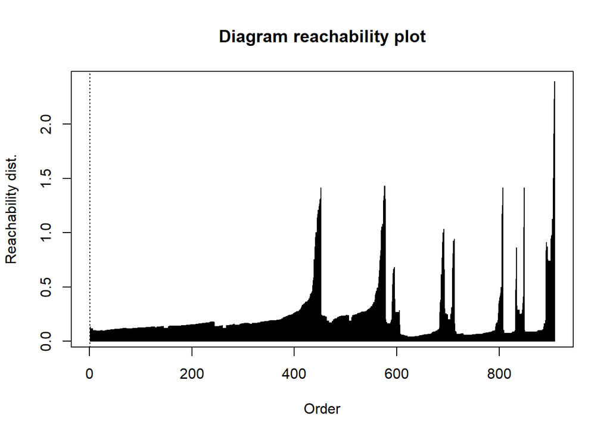

```r
plot(res2, main= "Diagram reachability plot")
```

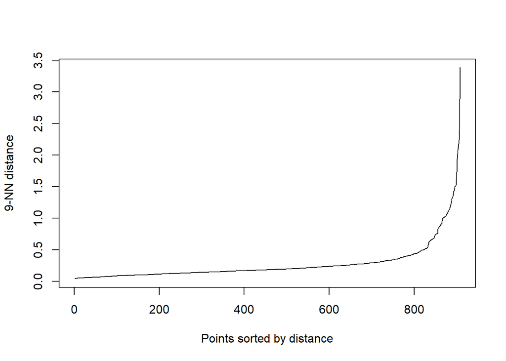

```r
k <- 9
kNNdistplot(hawks_scaled, k = k)
```

We can see that the elbow continues to rise drastically, even a bit later from **0.6 to 0.8**, shifting to a mean of **0.7**. We will introduce this new change in epsilon.

```r
res2 <- extractDBSCAN(res2, eps_cl = 0.7)
res2
```

```
## OPTICS ordering/clustering for 908 objects.
## Parameters: minPts = 10, eps = 3.40653377439247, eps_cl = 0.7, xi = NA
## The clustering contains 8 cluster(s) and 51 noise points.
##
##   0   1   2   3   4   5   6   7   8
##  51 438 115 110  18  93  27  14  42
##
## Available fields: order, reachdist, coredist, predecessor, minPts, eps,
##                   eps_cl, xi, cluster
```

As expected, the number of clusters changes radically, we now have **8** clusters and much more noise, as seen in the plot.

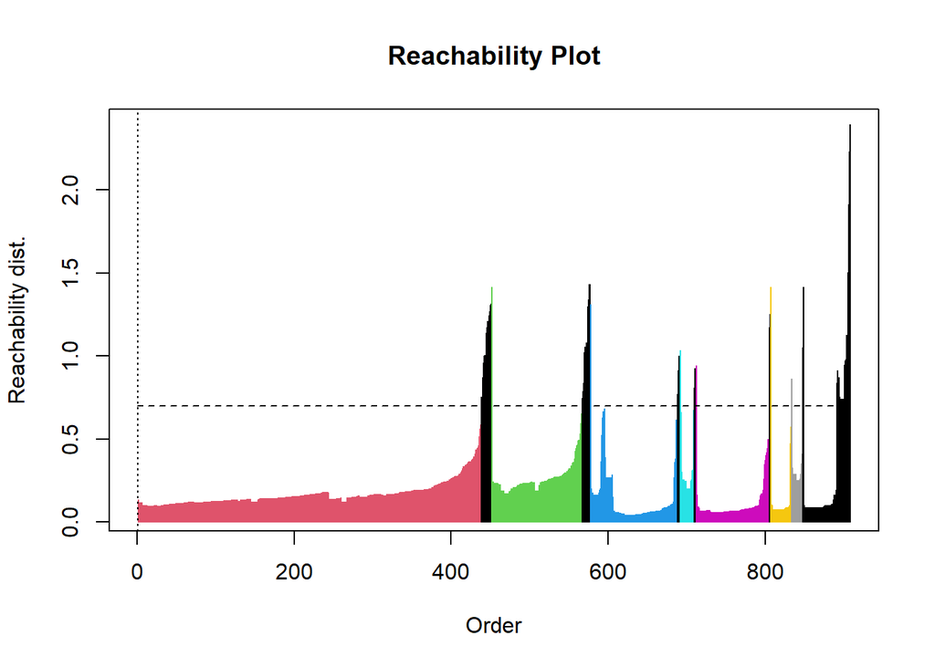

```r
plot(res2)
```

Upon plotting, we see that the clusters themselves overlap, concluding that this analysis is not valid and is erroneous.

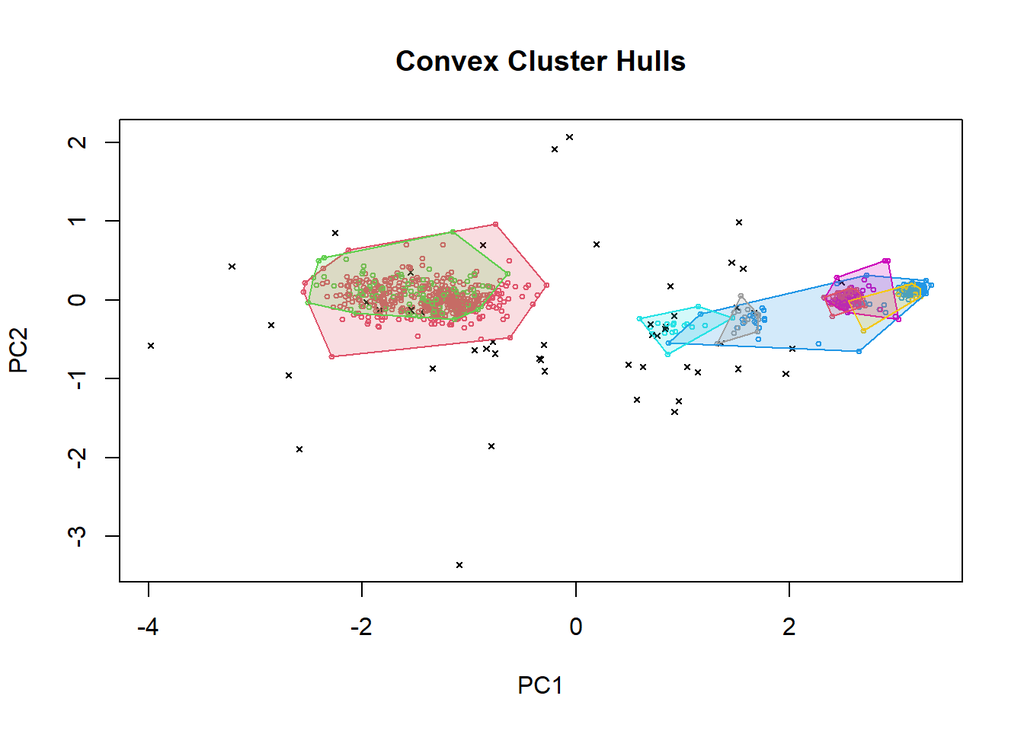

```r
hullplot(hawks_scaled2, res2)
```

We return to our normalized dataset without the dummy attributes and change the epsilon value to **0.6** and **0.61**, determining if we see significant changes since we are right on the limit.

```r
res06 <- extractDBSCAN(res, eps_cl = 0.6)
res06
```

```
## OPTICS ordering/clustering for 908 objects.
## Parameters: minPts = 10, eps = 3.07488223798005, eps_cl = 0.6, xi = NA
## The clustering contains 3 cluster(s) and 29 noise points.
##
##   0   1   2   3
##  29 559  61 259
##
## Available fields: order, reachdist, coredist, predecessor, minPts, eps,
##                   eps_cl, xi, cluster
```

```r
res61 <- extractDBSCAN(res, eps_cl = 0.61)
res61
```

```
## OPTICS ordering/clustering for 908 objects.
## Parameters: minPts = 10, eps = 3.07488223798005, eps_cl = 0.61, xi = NA
## The clustering contains 2 cluster(s) and 28 noise points.
##
##   0   1   2
##  28 559 321
##
## Available fields: order, reachdist, coredist, predecessor, minPts, eps,
##                   eps_cl, xi, cluster
```

**Conclusions ESP**

The tests with eps_cl values of **0.55**, **0.6**, and **0.61** for the OPTICS algorithm provide a clear insight into the sensitivity of the epsilon parameter in cluster identification. With eps_cl = 0.55 and eps_cl = 0.6, OPTICS identifies **3 clusters**, with a small variation in the number of noise points (**31** and **29**, respectively). However, when increasing eps_cl to **0.61**, the number of clusters reduces to **2**, and the noise points decrease to **28**.

This indicates that the epsilon value within the range of **0.55 to 0.61** is a critical margin where small changes can significantly affect the clustering structure. This behavior suggests that the data has variable density, which is sensitive to epsilon adjustments, affecting the algorithm’s ability to differentiate between dense clusters and noise points.

# Exercise 3: Comparison of *k-means* and *DBSCAN* Methods

- **https://blogdatlas.wordpress.com/2024/04/06/clusterizacion-espacial-k-means-vs-dbscan-descripcion-y-ejemplo-practico-con-qgis-columna-de-investigacion-datlas/**
- **https://www.geeksforgeeks.org/difference-between-k-means-and-dbscan-clustering/**
- **https://www.kaggle.com/code/ahmedmohameddawoud/dbscan-vs-k-means-visualizing-the-difference**
- **https://hex.tech/blog/comparing-density-based-methods/**

## Comparison of *k-means* and *DBSCAN* Methods

Each of these clustering algorithms has its pros and cons. Choosing the best one depends on the structure and characteristics of the dataset and the purpose of the clustering. For example, if we want to group customers and need all the data to belong to a group, K-means is useful because it guarantees that each data point will belong to a cluster. On the other hand, if we want to filter noise and focus only on certain subsets, DBSCAN is better, as it allows ignoring isolated data points and focusing only on the most relevant ones, such as in an analysis of areas with prospect potential.

### Comparison of Algorithms

K-means forms spherical clusters and requires specifying the number of groups beforehand. It is efficient with large datasets and is not affected by the variation in densities between points. However, it is sensitive to noise and outliers, which can distort the formation of clusters and make anomaly detection difficult. It only needs to define one parameter: the desired number of clusters (K).

On the other hand, DBSCAN creates irregularly shaped clusters of variable sizes without needing to specify the number of groups beforehand. Although not as efficient with high-dimensional data, it handles noise well and can mark certain points as “noise” or out of the clusters, making anomaly detection easier. However, it is sensitive to the choice of its two parameters: the neighborhood radius (R) and the minimum number of points (M) in that neighborhood, and it doesn’t perform well with sparse data or with highly variable densities.

Both algorithms have strengths: K-means works well on large, uniform data, while DBSCAN excels with complex densities and noise. The choice between them should be based on the type of data and the specific needs of the analysis.

### Real-world Comparison

In a study conducted by Schubert et al. (2017), K-Means and DBSCAN were compared on simulated datasets with different density and shape configurations. The results showed that DBSCAN outperformed K-Means in situations where clusters had different shapes and sizes, while K-Means was more efficient in uniformly distributed data. This study illustrates how the choice of algorithm can significantly affect data interpretation.  
A practical use case is in analyzing customer data in the retail sector. If K-Means is used, the segmentation may be appropriate if customers group consistently and without significant outliers. However, if the data contains customers with extreme behaviors, DBSCAN could provide better insights by identifying those outliers and preserving the integrity of the main clusters.

### Conclusion

The choice between K-Means and DBSCAN depends on the type of data and the application context. K-Means is preferable for well-structured and spherical data, while DBSCAN is the best choice for data with complex shapes and the presence of outliers. Understanding the characteristics of each algorithm allows analysts to select the most suitable one, thus improving the quality of the results and data-driven decision-making.

## Comparison of *k-means* and *DBSCAN* Methods in Our Analysis

The analysis conducted concludes that, in the dataset used, three heterogeneous groups were identified, and DBSCAN and OPTICS methods outperformed K-means, especially in a dataset with much noise and variability. However, the results were not entirely satisfactory.

### Comparison of Clustering Methods: K-means and DBSCAN

**K-means:** A prototype-based clustering method that seeks to minimize the variance within each group. While simple and effective, it requires knowing the number of clusters beforehand and tends to form circular clusters, which limits its usefulness in noisy datasets or datasets with complex shapes.

**DBSCAN:** A density-based method that groups points with a high concentration in their neighborhood, allowing the identification of non-linear clusters and handling noise and outliers well. However, it is sensitive to the input parameters, and its performance can be affected in high-dimensional datasets.

**OPTICS** was explored as an extension of DBSCAN, which allows identifying clusters with variable densities and represents the results graphically, facilitating analysis in contexts where clustering patterns are not obvious.

## Final Conclusions in Comparison of Results

When applying both methods to a dataset of raptor birds, it was observed that K-means generated uniform clusters with good separation, while DBSCAN identified more complex and dense clusters and handled noise better. OPTICS provided a useful visual representation of the structure and density of the data.

Both methods can be useful, depending on the nature of the dataset and the research questions.